# EDLD 651 Final Project

**Paper**

### The Population Assessment of Tobacco and Health (PATH): A Secondary Data Analysis

Aden Bhagwat, Maya Casper, Emily Mingus, Andrew Prior

#### Abstract

The Population Assessment of Tobacco and Health (PATH) aims to investigate the important attitudes and behaviors of adolescents towards tobacco and nicotine-related substances. Prior research indicates that individual attitudes towards substances can affect substance use. We used this rich dataset to further look into research questions relating to smoker identification, beliefs about smoking cigarettes, and cigarette smoking behaviors in the past 30 days. While most results were null, we offer potential explanations including ceiling effects and lack of statistical power. We did find that identification as a smoker significantly predicts smoking behavior. Future research can seek to disrupt this smoker identification to decrease subsequent smoking behavior, as well as continue researching the effects of cigarette attitudes on smoking behavior. Future research should also ensure diverse datasets, representative by gender, race, and socioeconomic status, to fairly capture external factors relating to smoking behavior.

#### Introduction

Adolescent tobacco use remains a critical public health concern, with significant implications for individual health, societal well-being, and policy structure and development. According to the CDC, it is estimated that 2.3% of adolescents 12-17 smoked in the past month (CDC 2019). Additionally, more recent statistics have estimated that 5.9% of students currently use e-cigarettes accounting for 1.63 million adolescents (CDC 2024). The Population Assessment of Tobacco and Health (PATH) Study was conducted by the National Institute on Drug Abuse (NIDA), the National Institutes of Health (NIH), the Center for Tobacco Products (CTP), and the Food and Drug Administration (FDA) represents a plethora of of data on tobacco-related attitudes and behaviors (United States Department of Health and Human Services 2024). This longitudinal study provides invaluable insights into how tobacco use patterns, attitudes, and exposure evolve over time. This is especially true among children and adolescents.

Since its inception in 2011, the PATH study has helped inform policy and other regulatory activities under the Family Smoking Prevention and Tobacco Control Act, which seeks to reduce tobacco use through evidence-based policies. This study recognizes the diverse forms of tobacco use including cigarettes, hookah, and smokeless tobacco and includes tobacco-related attitudes including perceived risks and social norms. It is because of this, the dataset has been instrumental in the creation of public health intervention and policy decisions. The study currently has six waves of data collection allowing for researchers to observe changes in perception in the United States as time goes on and with the introduction of new products. For the purposes of this study, the team utilized Wave 6 (2021), using the publicly available data from youth and parent questionnaire responses to dig deeper into adolescent smoking behaviors (United States Department of Health and Human Services 2024).

An increasing amount of literature underscores the multi-faceted factors influencing youth smoking. Specifically, qualitative studies emphasize the role of the smoker identity in shaping smoking behaviors including cessation efforts and coping mechanisms (Hertel 2016; Tombor 2015). Smoker identity is characterized by the internalization of smoking as a core aspect of self and has been linked to higher smoking frequency and socially motivated smoking behaviors (Tombor 2015). Conversely, nonsmokers can benefit from a more favorable social standing and greater empathy towards smokers who struggle with addiction (McCool 2013).

Despite these insights, there are remaining questions regarding the nuanced relationship between adolescents’ attitudes towards smoking, smoker identity, and smoking behaviors. Specifically, this study aims to answer the following research questions:

1. What is the prevalence of adolescent smoking (ages 12-17) and how is it distributed across demographic factors including age, sex, race and socioeconomic status?
2. How does smoker identity contribute to past 30-day smoking frequency among adolescents?
3. How are attitudes toward the harmfulness and addictiveness of cigarettes associated with past 30-day smoking frequency among adolescents?

By utilizing the robust PATH dataset, we hope to contribute to a deeper understanding of adolescent smoking behaviors to inform targeted interventions that address both psychological and social underlying mechanisms of youth tobacco use.

### Methods

#### Participants:

This study conducted secondary analysis of data from the Population Assessment of Tobacco and Health (PATH) Study. The PATH Study is a longitudinal, multiwave study – facilitated by agencies including the US Department of Health and Human Services (USDHHS), the National Institute on Drug Abuse (NIDA), the National Institutes of Health (NIH), the Center for Tobacco Products (CTP), and the Food and Drug Administration (FDA) – that focuses on attitudes toward tobacco and tobacco use behaviors among adolescents aged 12-17 (United States Department of Health and Human Services 2024). Specifically, our team analyzed data from the most recent publicly available data, which comprises youth and parent questionnaire responses collected in 2021. Given that our research questions centered on the associations between youth beliefs about tobacco and smoker identity, as well as self-reported cigarette use, responses were filtered to include only participants who responded – affirmatively or negatively – to the survey question “Do you consider yourself a smoker?”

#### Meaures:

*Outcome Variables*

Our study posited two outcomes of interest as a potential function of youth tobacco attitudes; these variables were 1) smoker identity and 2) past-30-day cigarette use frequency. The former outcome was measured by the aforementioned question, “Do you consider yourself a smoker?”, and thus represented as a dichotomous, categorical variable. The latter was represented as a numerical variable and elicited in response to the question, “In the past 30 days, how many days did you use cigarettes?”

*Attitudes Toward Tobacco*

Two tobacco-related attitudes were operationalized as predictor variables: beliefs about the perceived harmfulness of cigarettes to health (“How harmful do you think cigarettes are to health?) and beliefs about the likelihood of someone becoming addicted to cigarettes (“How likely is someone to become addicted to cigarettes?”). In the parent study, responses to both items were measured via Likert-style scales scored from 1 (“Not at all harmful;” “Very unlikely”) to 5 (“Extremely harmful;” “Extremely likely”). In modeling relationships between these predictors and our outcomes of interest, we approached both tobacco-related attitudes as categorical variables rather than assuming numeric uniformity in the degree of difference between response levels.

*Covariate Controls*

Prior research has indicated that 12th graders report significantly higher daily cigarette use versus 9th, 10th, and 11th graders; that boys report significantly higher daily cigarette use than girls; and that Latinx and White youth report significantly higher daily cigarette use than Black and Asian youth (Mejia 2023). Participants’ age, sex, and race were therefore operationalized as covariate controls. Robust evidence also links higher smoking prevalence to lower socioeconomic status (SES) and suggests that smokers of disadvantaged economic circumstances may incur greater tobacco-related harms (Hiscock 2012). SES was accordingly operationalized as an additional covariate control. The parent study measured age as a categorical variable with two levels: “12-14” and “15-17.” The parent study measured SES as a categorical variable with five levels corresponding to annual household income under $10,000, between $10,000 and $24,999, between $25,000 and $49,999, between $50,000 and $99,999, and over $100,000. Sex and race were measured as categorical variables as well.

### Analytic Strategy:

#### Analyses

Logistic regression was used to model potential associations between the two tobacco attitude variables – beliefs about cigarette harmfulness and likelihood of addiction – and smoker identity. General linear regression was used to model potential associations between the two tobacco attitude variables and past-30-day tobacco use frequency. To account for the possibility that five levels of respondents’ perceived harmfulness of cigarettes and perceived likelihood of addiction might dilute between-group differences in effect size, these four models were subsequently re-run with a mutated dataset that collapsed both attitude variables into three levels: (“Not harmful”/”Not likely”; “Somewhat harmful”/”Neither likely nor unlikely”; “Harmful”/”Likely”). Last, a general linear regression was used to model the relationship between smoker identity and past-30-day frequency of cigarette use. All models controlled for age, sex, race, and SES.

### Results

Table 1 presents descriptive statistics of the full PATH study sample (n = 5,652). Table 2 presents descriptive statistics of the sample subset (n = 370) who responded affirmatively or negatively to the smoker identity question. Demographics were fairly consistent between those self-identified as smokers as compared to non-smokers for gender and race variables. However, there was a discrepancy for socioeconomic status, where the largest income group for non-smokers was $50,000 to $99,999 (28%), but for smokers was $25,000 to $49,999 (42%). Coefficients for logistic regression models predicting smoker identity represent the odds ratio (OR): in this case, the odds of a participant self-identifying as a smoker relative to their odds of identifying as a non-smoker given the presence/absence of a particular variable. As illustrated by Table 3, no levels of participants’ perceived harmfulness of cigarettes (modeled as a five-dimensional factor) were significantly associated with their odds of self-identifying as a smoker. These null results were replicated by subsequent analyses that modeled perceived cigarette harmfulness as a three-dimensional factor. As illustrated by Table 4, no levels of participants’ perceived likelihood of cigarette addiction (modeled as a five-dimensional factor) were significantly associated with their odds of self-identifying as a smoker. These null results were replicated by subsequent analyses that modeled perceived likelihood of addiction as a three-dimensional factor.

As illustrated by Table 5, no levels of participants’ perceived harmfulness of cigarettes (modeled as a five-dimensional factor) were significantly associated with their self-reported past-30-day frequency of cigarette use. These null results were replicated by subsequent analyses that modeled perceived cigarette harmfulness as a three-dimensional factor. As illustrated by Table 6, no levels of participants’ perceived likelihood of cigarette addiction (modeled as a five-dimensional factor) were significantly associated with their self-reported past-30-day frequency of cigarette use. These null results were replicated by subsequent analyses that modeled perceived likelihood of addiction as a three-dimensional factor. Last, as illustrated by Table 7, participants’ smoker identity was significantly associated (p < 0.001) with their self-reported past-30-day frequency of cigarette use. On average in the study sample subset who either affirmed or denied smoker identity (n = 370), and while adjusting for age, sex, race, and SES, smoker identity was associated with 12.46 more days of cigarette use than non-smoker identity.

### Dicussion

Theoretically, there may truly be no difference in smoking habits between participants who believed cigarettes are harmful/addictive and those who did not. Murphy (2001) found that an educational intervention changed behaviors for the heaviest drinking participants, but not for the sample as a whole. We may be seeing a similar effect, where knowledge of harm/addictiveness does not necessarily affect behaviors for most participants. In future research, it would be interesting to segment a larger sample of smokers into levels of smoking behavior, and see if attitudes or attitude changes play a larger role in predicting behaviors among this group.

One hypothesis that was supported was that participants who self-identified as smokers were more likely to have smoked cigarettes in the past 30 days. This was consistent with existing literature where the relationship between smoker identity and cigarette usage has been well explored.

These results highlight the importance of comprehensive multi-component interventions to reduce tobacco use among adolescents. The null findings in the associations between perceptions of harmfulness and potential for addiction and smoking status indicate that knowledge of the harms of tobacco use alone does little to deter smoking. Instead of relying solely on health education for prevention efforts, paired education and behavioral interventions will likely have a larger effect on smoking among this population. Future studies should continue to consider multi-component programming to prevent the initiation of smoking by adolescents. Future studies should also ensure that samples are representative of the general population- our sample may have included some bias, mainly that higher socioeconomic status (SES) families may have been overrepresented. The largest proportion of the sample (37%) indicated a family income of over $100,000 a year, while the national median household income is closer to $80,000. This may be particularly relevant to our sample, as low SES has been correlated to increased cigarette use (Hiscock 2012).

**Visuals**

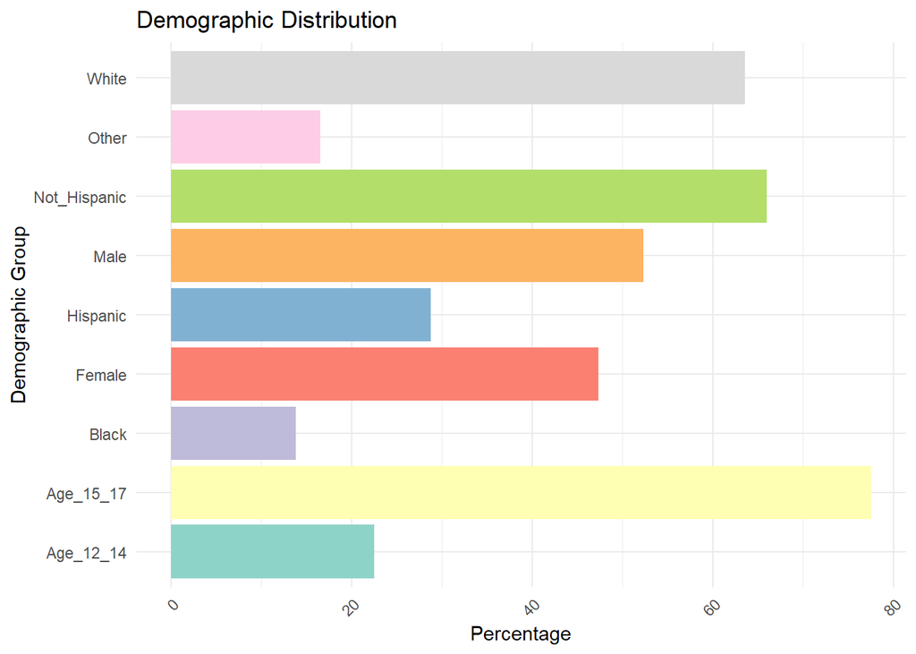

Table 1: Demographic Distribution of Participants

| Demographic | Count | Percentage |
| --- | --- | --- |
| Male | 2958 | 52.34 |
| Female | 2674 | 47.31 |
| Ages 12-14 | 1271 | 22.49 |
| Ages 15-17 | 4381 | 77.51 |
| Hispanic | 1626 | 28.77 |
| Not Hispanic | 3732 | 66.03 |
| White | 3594 | 63.59 |
| Black | 783 | 13.85 |
| Other | 937 | 16.58 |

Table 2: Demographic Distribution of Self-Identified Smokers and Non-Smokers

| Demographic | Count | Percentage |
| --- | --- | --- |
| Male | 204 | 55.14 |
| Female | 166 | 44.86 |
| Ages 12-14 | 36 | 9.73 |
| Ages 15-17 | 334 | 90.27 |
| Hispanic | 98 | 26.49 |
| Not Hispanic | 257 | 69.46 |
| White | 253 | 68.38 |
| Black | 38 | 10.27 |
| Other | 68 | 18.38 |

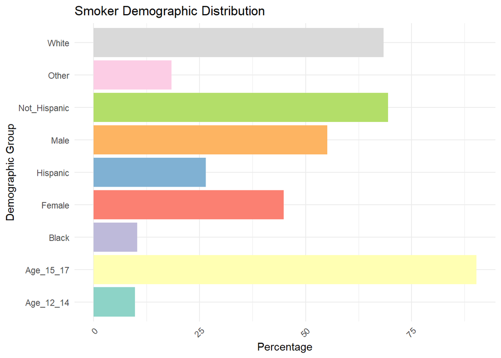

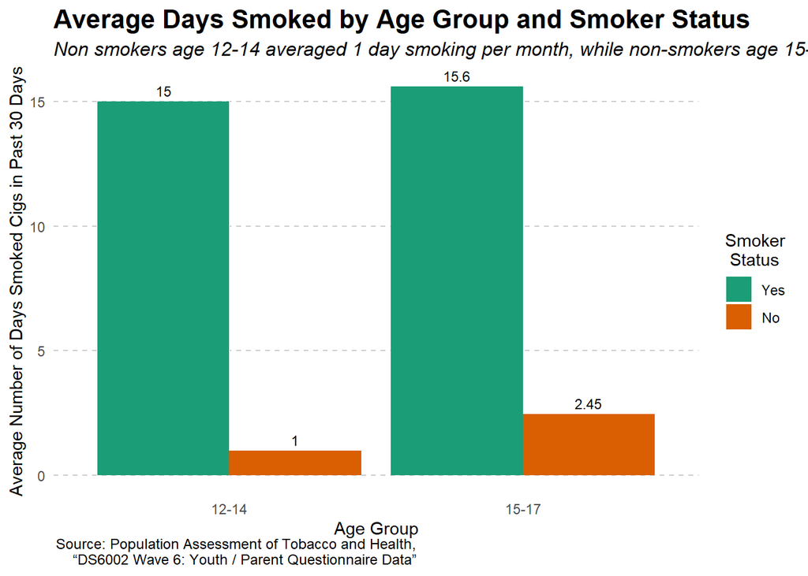

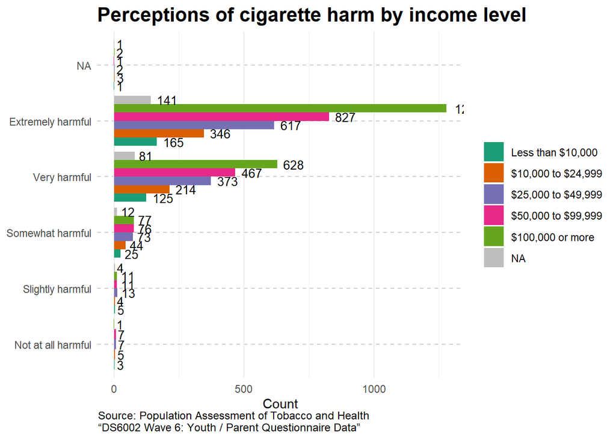

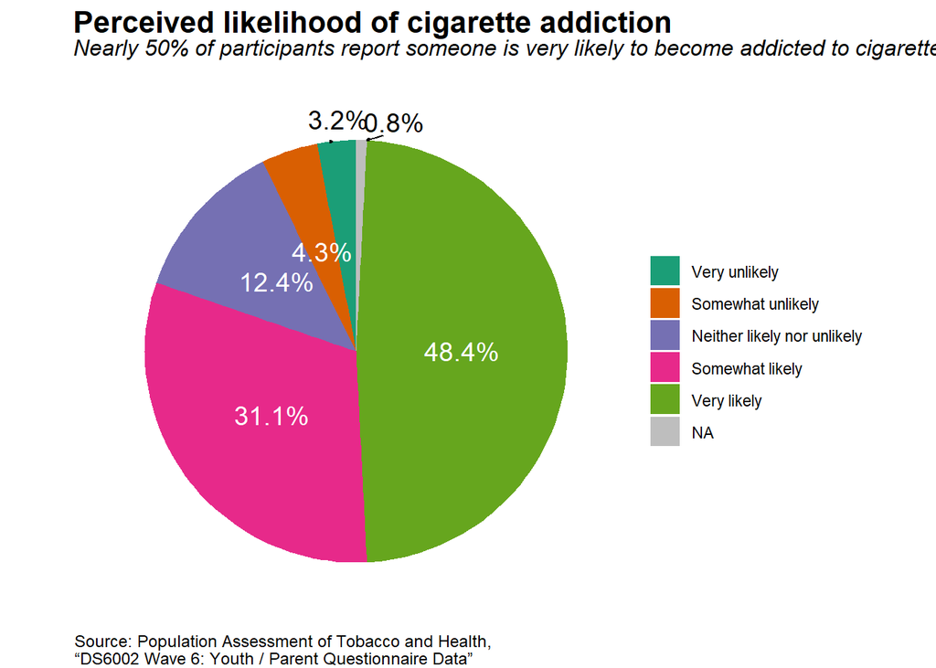

Table 3: Associations Between Perceived Cigarette Harmfulness and Smoker Identity

|  | estimate | std_error | z_value | p_value |
| --- | --- | --- | --- | --- |
| Intercept | 5.86 | 1.31 | 1.35 | 0.18 |
| Slightly Harmful | 0.56 | 1.47 | -0.39 | 0.69 |
| Somewhat Harmful | 0.76 | 1.23 | -0.22 | 0.83 |
| Very Harmful | 1.33 | 1.20 | 0.24 | 0.81 |
| Extremely Harmful | 2.89 | 1.23 | 0.86 | 0.39 |
| Age 15-17 | 0.89 | 0.59 | -0.20 | 0.84 |
| Female | 0.71 | 0.36 | -0.93 | 0.35 |
| Black | 0.63 | 0.52 | -0.90 | 0.37 |
| Other Racial Identity | 1.57 | 0.52 | 0.86 | 0.39 |
| $10,000-24,999 | 1.71 | 0.70 | 0.77 | 0.44 |
| $25,000-49,999 | 0.62 | 0.54 | -0.88 | 0.38 |
| $50,000-99,999 | 1.76 | 0.60 | 0.94 | 0.35 |
| Over $100,000 | 1.31 | 0.63 | 0.43 | 0.67 |

Table 4: Associations Between Beliefs about Likelihood of Addiction and Smoker Identity

|  | estimate | std_error | z_value | p_value |
| --- | --- | --- | --- | --- |
| Intercept | 12.92 | 1.21 | 2.11 | 0.03 |
| Somewhat Unlikely | 4541051.98 | 1161.79 | 0.01 | 0.99 |
| Neither Likely nor Unlikely | 0.31 | 1.14 | -1.02 | 0.31 |
| Somewhat Likely | 0.66 | 1.12 | -0.37 | 0.71 |
| Very Likely | 1.01 | 1.10 | 0.01 | 1.00 |
| Age 15-17 | 0.91 | 0.59 | -0.16 | 0.87 |
| Female | 0.64 | 0.36 | -1.24 | 0.22 |
| Black | 0.69 | 0.52 | -0.72 | 0.47 |
| Other Racial Identity | 1.81 | 0.52 | 1.14 | 0.26 |
| $10,000-24,999 | 1.58 | 0.70 | 0.66 | 0.51 |
| $25,000-49,999 | 0.53 | 0.53 | -1.20 | 0.23 |
| $50,000-99,999 | 1.78 | 0.60 | 0.96 | 0.34 |
| Over $100,000 | 1.14 | 0.63 | 0.21 | 0.83 |

Table 5: Associations between Perceived Cigarette Harmfulness and Past-30-Day Smoking Frequency (# Days Smoked)

|  | estimate | std_error | t_value | p_value |
| --- | --- | --- | --- | --- |
| Intercept | 17.12 | 10.38 | 1.65 | 0.11 |
| Slightly Harmful | -0.75 | 12.61 | -0.06 | 0.95 |
| Somewhat Harmful | -7.78 | 10.87 | -0.72 | 0.48 |
| Very Harmful | -7.82 | 11.00 | -0.71 | 0.48 |
| Extremely Harmful | -7.43 | 11.35 | -0.65 | 0.52 |
| Age 15-17 | -0.22 | 4.94 | -0.05 | 0.96 |
| Female | -5.49 | 2.98 | -1.84 | 0.07 |
| Black | 0.33 | 4.07 | 0.08 | 0.94 |
| Other Racial Identity | -1.63 | 4.39 | -0.37 | 0.71 |
| $10,000-24,999 | -1.57 | 5.23 | -0.30 | 0.77 |
| $25,000-49,999 | 8.37 | 3.88 | 2.16 | 0.04 |
| $50,000-99,999 | -2.06 | 4.06 | -0.51 | 0.61 |
| Over $100,000 | -4.68 | 4.05 | -1.15 | 0.25 |

Table 6: Associations Between Beliefs about Likelihood of Addiction and Past-30-Day Smoking Frequency (# Days Smoked)

|  | estimate | std_error | t_value | p_value |
| --- | --- | --- | --- | --- |
| Intercept | 13.82 | 7.73 | 1.79 | 0.08 |
| Neither Likely nor Unlikely | -4.49 | 7.50 | -0.60 | 0.55 |
| Somewhat Likely | -3.58 | 7.26 | -0.49 | 0.62 |
| Very Likely | -5.61 | 7.41 | -0.76 | 0.45 |
| Age 15-17 | -0.12 | 4.49 | -0.03 | 0.98 |
| Female | -4.37 | 2.87 | -1.52 | 0.13 |
| Black | 0.02 | 4.05 | 0.00 | 1.00 |
| Other Racial Identity | -2.16 | 4.23 | -0.51 | 0.61 |
| $10,000-24,999 | -1.77 | 5.18 | -0.34 | 0.73 |
| $25,000-49,999 | 8.50 | 3.80 | 2.23 | 0.03 |
| $50,000-99,999 | -2.59 | 4.13 | -0.63 | 0.53 |
| Over $100,000 | -4.64 | 4.10 | -1.13 | 0.26 |

Table 7: Associations Between Smoker Identity and Past-30-Day Smoking Frequency (# Days Smoked)

|  | estimate | std_error | t_value | p_value |
| --- | --- | --- | --- | --- |
| Intercept | 16.41 | 3.67 | 4.47 | 0.00 |
| Non-Smoker | -12.46 | 2.19 | -5.68 | 0.00 |
| Age 15-17 | 1.05 | 3.17 | 0.33 | 0.74 |
| Female | -6.30 | 2.16 | -2.92 | 0.01 |
| Black | -3.54 | 3.13 | -1.13 | 0.26 |
| Other Racial Identity | 0.79 | 3.24 | 0.24 | 0.81 |
| $10,000-24,999 | -2.21 | 3.95 | -0.56 | 0.58 |
| $25,000-49,999 | 4.30 | 2.98 | 1.44 | 0.16 |
| $50,000-99,999 | -0.54 | 3.09 | -0.17 | 0.86 |
| Over $100,000 | -2.56 | 3.05 | -0.84 | 0.41 |

## References

CDC. 2019. “National Center for Health Statistics.”

———. 2024. “E-Cigarette Use Among Youth. Smoking and Tobacco Use.”

Hertel, & Mermelstein, A. W. 2016. “Smoker Identity Development Among Adolescents Who Smoke.” *Psychology of Addictive Behaviors* 30 (4): 475–83. https://doi.org/10.1037/adb0000171.

Hiscock, Bauld, R. 2012. “Socioeconomic Status and Smoking: A Review.” *Annals of the New York Academy of Sciences* 1248: 107–23. https://doi.org/10.1111/j.1749-6632.2011.06202.x.

McCool, Hoek, J. 2013. “Crossing the Smoking Divide for Young Adults: Expressions of Stigma and Identity Among Smokers and Nonsmokers.” *Nicotine & Tobacco Research: Official Journal of the Society for Research on Nicotine and Tobacco* 15 (2): 522–56. https://doi.org/10.1093/ntr/nts136.

Mejia, Adele, M. C. 2023. “Trends in Cigarette Smoking Among United States Adolescents.” *Ochsner Journal* 23 (4): 289–95. https://doi.org/10.31486/toj.23.0113.

Murphy, Duchnick, J. G. 2001. “Relative Efficacy of a Brief Motivational Intervention for College Student Drinkers.” *Psychology of Addictive Behaviors* 15 (4): 373–79. https://doi.org/10.1037//0893-164x.15.4.373.

Tombor, Shahab, I. 2015. “Smoker Identity and Its Potential Role in Young Adults’ Smoking Behavior: A Meta-Ethnography.” *Health Psychology* 34 (10): 992–1003. https://doi.org/10.1037/hea0000191.

United States Department of Health and Human Services. 2024. “Population Assessment of Tobacco and Health (PATH) Study Public-Use Files. Inter-University Consortium for Political and Social Research.”